# Data 624 Project 2: pH Prediction in Beverage Manufacturing

Michael Robinson and Steven Gonzalez

5/18/2025

## Prompt

This is role playing. I am your new boss. I am in charge of production at ABC Beverage and you are a team of data scientists reporting to me. My leadership has told me that new regulations are requiring us to understand our manufacturing process, the predictive factors and be able to report to them our predictive model of PH.

Please use the historical data set I am providing. Build and report the factors in BOTH a technical and non-technical report. I like to use Word and Excel. Please provide your non-technical report in a business friendly readable document and your predictions in an Excel readable format. The technical report should show clearly the models you tested and how you selected your final approach.

## Approach

Any data analysis revolving around forecasts and the prediction of variables will need to take into consideration the best predictive model to do the job. For this analysis, we will first familiarize ourselves with the data at hand by looking at its content, distribution, skewness and any possible relationships between the predictive variables. We will then take the observations we made and perform the necessary transformations to prepare the data for analysis. Once prepared, we will build and train different predictive models using the data. Finally, we will assess which model performed the best and apply it to predictions on our test data.

## Data Exploration

We start off by loading the data and taking a glimpse into its content. Afterwards, we assess pH and predictor distributions, skewness, and relationships.

### Load and View Data

```r
training <- read.csv("https://raw.githubusercontent.com/Stevee-G/Data624/refs/heads/main/Project2/TrainingData.csv")
testing <- read.csv("https://raw.githubusercontent.com/Stevee-G/Data624/refs/heads/main/Project2/TestData.csv")

str(training)
```

```
## 'data.frame':    2571 obs. of  33 variables:
##  $ Brand.Code       : chr  "B" "A" "B" "A" ...
##  $ Carb.Volume      : num  5.34 5.43 5.29 5.44 5.49 ...
##  $ Fill.Ounces      : num  24 24 24.1 24 24.3 ...
##  $ PC.Volume        : num  0.263 0.239 0.263 0.293 0.111 ...
##  $ Carb.Pressure    : num  68.2 68.4 70.8 63 67.2 66.6 64.2 67.6 64.2 72 ...
##  $ Carb.Temp        : num  141 140 145 133 137 ...
##  $ PSC              : num  0.104 0.124 0.09 NA 0.026 0.09 0.128 0.154 0.132 0.014 ...
##  $ PSC.Fill         : num  0.26 0.22 0.34 0.42 0.16 0.24 0.4 0.34 0.12 0.24 ...
##  $ PSC.CO2          : num  0.04 0.04 0.16 0.04 0.12 0.04 0.04 0.04 0.14 0.06 ...
##  $ Mnf.Flow         : num  -100 -100 -100 -100 -100 -100 -100 -100 -100 -100 ...
##  $ Carb.Pressure1   : num  119 122 120 115 118 ...
##  $ Fill.Pressure    : num  46 46 46 46.4 45.8 45.6 51.8 46.8 46 45.2 ...
##  $ Hyd.Pressure1    : num  0 0 0 0 0 0 0 0 0 0 ...
##  $ Hyd.Pressure2    : num  NA NA NA 0 0 0 0 0 0 0 ...
```

[output cut: 19 more lines]

```r
str(testing)
```

```
## 'data.frame':    267 obs. of  33 variables:
##  $ Brand.Code       : chr  "D" "A" "B" "B" ...
##  $ Carb.Volume      : num  5.48 5.39 5.29 5.27 5.41 ...
##  $ Fill.Ounces      : num  24 24 23.9 23.9 24.2 ...
##  $ PC.Volume        : num  0.27 0.227 0.303 0.186 0.16 ...
##  $ Carb.Pressure    : num  65.4 63.2 66.4 64.8 69.4 73.4 65.2 67.4 66.8 72.6 ...
##  $ Carb.Temp        : num  135 135 140 139 142 ...
##  $ PSC              : num  0.236 0.042 0.068 0.004 0.04 0.078 0.088 0.076 0.246 0.146 ...
##  $ PSC.Fill         : num  0.4 0.22 0.1 0.2 0.3 0.22 0.14 0.1 0.48 0.1 ...
##  $ PSC.CO2          : num  0.04 0.08 0.02 0.02 0.06 NA 0 0.04 0.04 0.02 ...
##  $ Mnf.Flow         : num  -100 -100 -100 -100 -100 -100 -100 -100 -100 -100 ...
##  $ Carb.Pressure1   : num  117 119 120 125 115 ...
##  $ Fill.Pressure    : num  46 46.2 45.8 40 51.4 46.4 46.2 40 43.8 40.8 ...
##  $ Hyd.Pressure1    : num  0 0 0 0 0 0 0 0 0 0 ...
##  $ Hyd.Pressure2    : num  NA 0 0 0 0 0 0 0 0 0 ...
```

[output cut: 19 more lines]

As can be seen above, the data sets are comprised of 33 variables each, 32 of them most likely being predictor variables. The training data set has 2571 observations while the testing data set has 267 observations.

### Assess PH Distributions by Brand Code

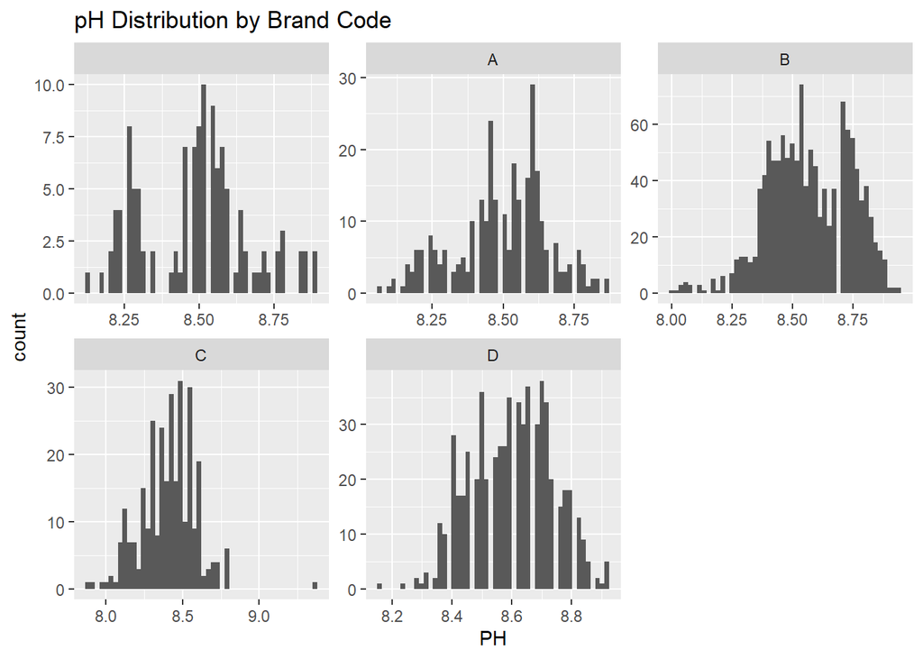

```r
training %>%
  ggplot() +
  aes(x = PH) +
  geom_histogram(bins= 50) +
  facet_wrap(~ Brand.Code, scales = "free") +
  labs(title = "pH Distribution by Brand Code")
```

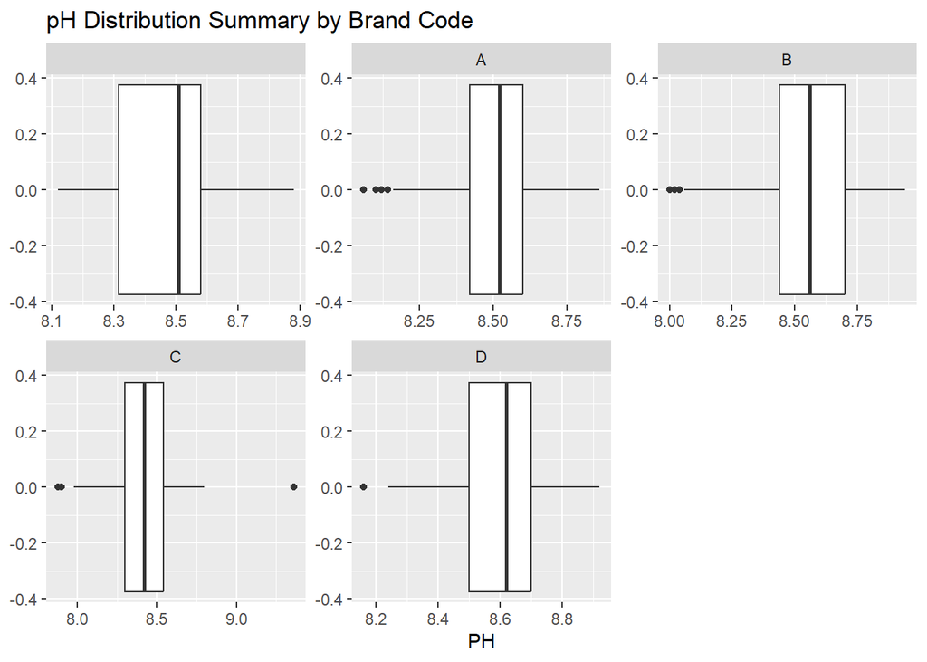

```r
training %>%
  ggplot() +
  aes(x = PH) +
  geom_boxplot() +
  facet_wrap(~ Brand.Code, scales = "free") +
  labs(title = "pH Distribution Summary by Brand Code")
```

Above we see that there seems to be some correlation between Brand and what pH they are likely to hover around. The box-plots show us that the brands are evenly distributed for the most part with “C” showing signs of skewness. The majority of them do contain outliers.

### Assess Predictor Distributions, Skewness, and Relationships

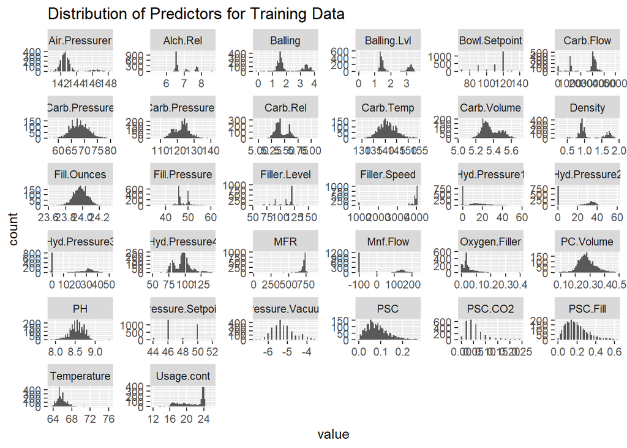

```r
training %>%
  select(where(is.numeric))%>%
  gather() %>%
  filter(!is.na(value)) %>%
  ggplot(aes(value)) +
  geom_histogram(bins = 50) +
  facet_wrap(~ key, scales = "free") +
  labs(title = "Distribution of Predictors for Training Data")
```

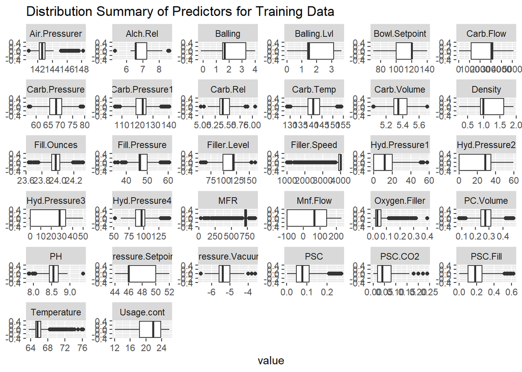

```r
training %>%
  select(where(is.numeric))%>%
  gather() %>%
  filter(!is.na(value)) %>%
  ggplot(aes(value)) +
  geom_boxplot() +
  facet_wrap(~key, scales = "free") +
  labs(title = "Distribution Summary of Predictors for Training Data")
```

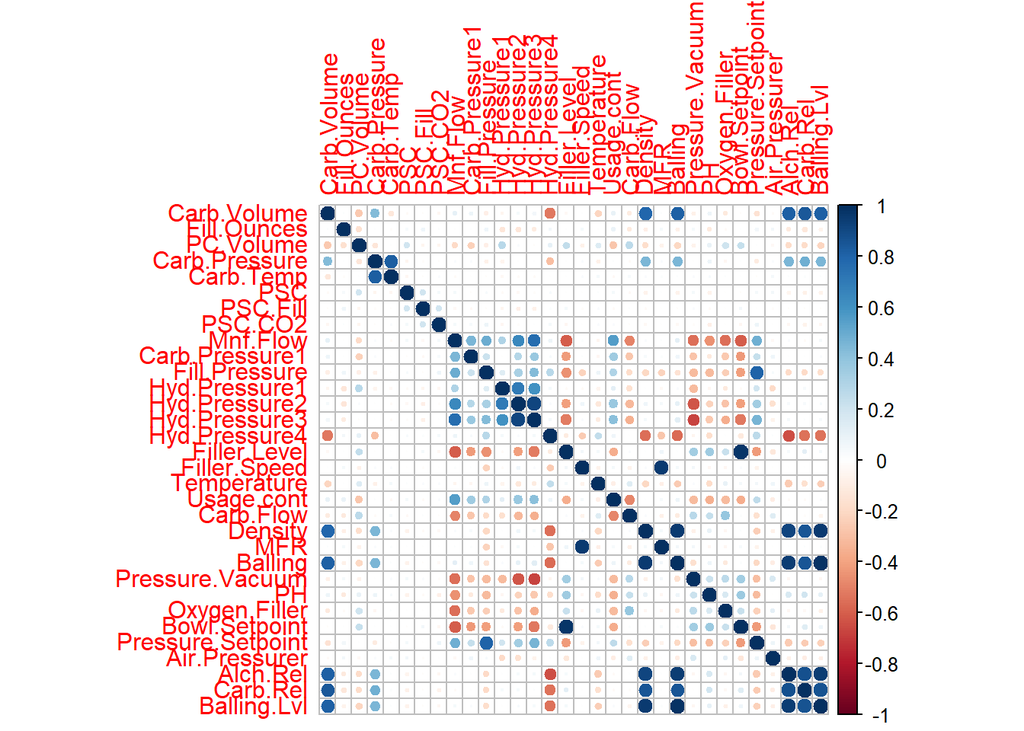

```r
training_cor <- cor(training %>%
                      select(where(is.numeric)),
                    use = "complete.obs")
corrplot(training_cor)
```

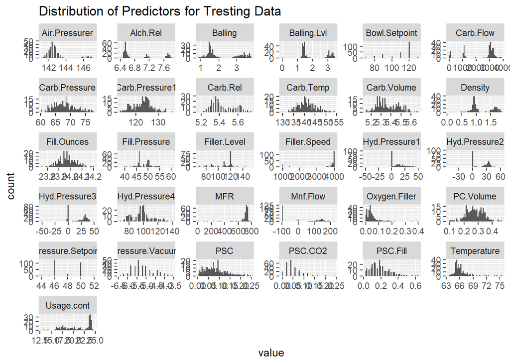

```r
testing %>%
  select(where(is.numeric)) %>%
  gather() %>%
  filter(!is.na(value)) %>%
  ggplot(aes(value)) +
  geom_histogram(bins = 50) +
  facet_wrap(~ key, scales = "free") +
  labs(title = "Distribution of Predictors for Tresting Data")
```

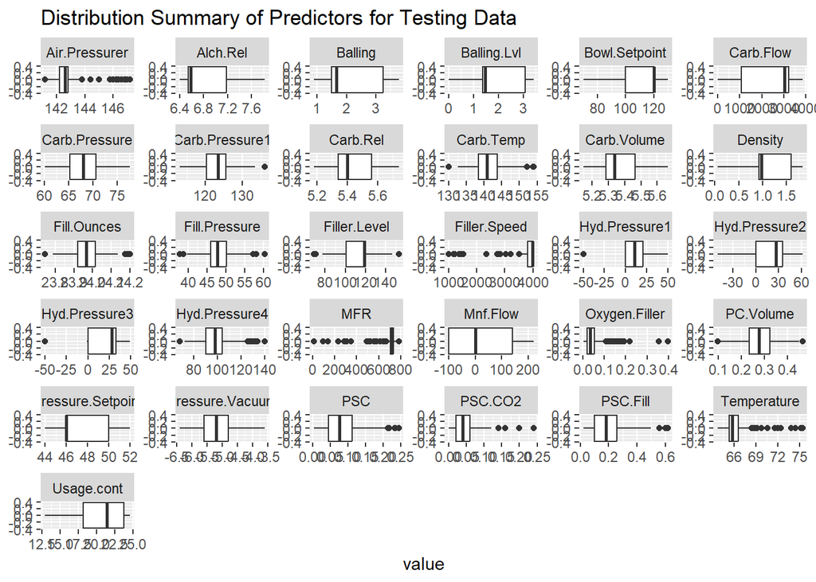

```r
testing %>%
  select(where(is.numeric)) %>%
  gather() %>%
  filter(!is.na(value)) %>%
  ggplot(aes(value)) +
  geom_boxplot() +
  facet_wrap(~key, scales = "free") +
  labs(title = "Distribution Summary of Predictors for Testing Data")
```

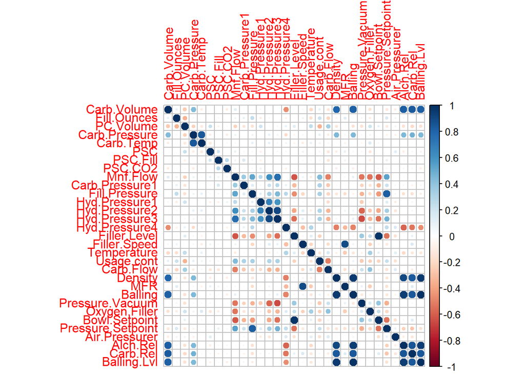

```r
testing_cor <- cor(testing %>%
                      select(where(is.numeric)),
                    use = "complete.obs")
corrplot(testing_cor)
```

The distributions for the predictor variables for both training and testing data seem to have some normal and some skewed. The same can be said for their respective box-plots along with the clear indication of outliers. Some distributions seem to be heavily contained over one specific region, suggesting the need to address degeneracy when preparing the data. The correlation plots for these variables seem to also indicate the need to address high correlation which could influence the performance of our models.

## Data Preparation

Now that we’ve familiarized ourselves with the data, we can begin preparing it for analysis. Once prepared, we are ready to run tests using our various models.

### Address Missing Data

```r
training %>%
  select(c(2:33)) %>%
  summarize_all(funs(sum(is.na(.)))) %>%
  pivot_longer(everything(),
               names_to = 'Predictor',
               values_to = 'Number of Missing Values')
```

```
## # A tibble: 32 × 2
##    Predictor      `Number of Missing Values`
##    <chr>                               <int>
##  1 Carb.Volume                            10
##  2 Fill.Ounces                            38
##  3 PC.Volume                              39
##  4 Carb.Pressure                          27
##  5 Carb.Temp                              26
##  6 PSC                                    33
##  7 PSC.Fill                               23
##  8 PSC.CO2                                39
##  9 Mnf.Flow                                2
## 10 Carb.Pressure1                         32
## # ℹ 22 more rows
```

```r
training <- kNN(training, k = 5) %>%
  select(c(1:33))

training %>%
  select(c(2:33)) %>%
  summarize_all(funs(sum(is.na(.)))) %>%
  pivot_longer(everything(),
               names_to = 'Predictor',
               values_to = 'Number of Missing Values')
```

```
## # A tibble: 32 × 2
##    Predictor      `Number of Missing Values`
##    <chr>                               <int>
##  1 Carb.Volume                             0
##  2 Fill.Ounces                             0
##  3 PC.Volume                               0
##  4 Carb.Pressure                           0
##  5 Carb.Temp                               0
##  6 PSC                                     0
##  7 PSC.Fill                                0
##  8 PSC.CO2                                 0
##  9 Mnf.Flow                                0
## 10 Carb.Pressure1                          0
## # ℹ 22 more rows
```

As can be seen from the above tibbles, the training data had many missing values. The MFR predictor had the most for a single variable. We went ahead and addressed these missing values using imputation through the k-nearest model. This resulted in values being filled taking into consideration up to the fifth nearest neighbor. The final tibble shows that there are no longer missing values after the procedure is done.

### Address Degenerate Variables

```r
nearZeroVar(training %>%
              select(c(2:33)), name = TRUE)
```

```
## [1] "Hyd.Pressure1"
```

```r
training <- training %>%
  select(-Hyd.Pressure1)
```

In order to check for degenerate and removable predictors we went ahead used the `nearZeroVar()` function. Doing so identified the “Hyd.Pressure1” predictor as problematic and needing to be removed. Therefore, we did exactly that.

### Address Highly Correlated Variables

```r
findCorrelation(testing_cor, cutoff = 0.9, names = TRUE)
```

```
## [1] "Balling"       "Hyd.Pressure3" "Alch.Rel"      "Density"
## [5] "Filler.Level"
```

```r
training <- training %>%
  select(-c(Balling, Hyd.Pressure3, Alch.Rel, Density, Filler.Level))
```

Next, we checked for predictors with high correlations, indicating their need for removal as well. Above we can see that “Balling”, “Hyd.Pressure3”, “Alch.Rel”, “Density”, and “Filler.Level” were identified to have high correlations and were thus removed.

## Assessing Models

Now that the data has been prepared, we can begin training our models and compare their respective performances in order to identify which one we will ultimately use for predicting pH values for our test data.

### Training Data Partitioning

```r
X <- training[ , !names(training) %in% c("PH")]
y <- training$PH

set.seed(123)

trainIndex <- createDataPartition(y, p = 0.8, list = FALSE)
X_train <- X[trainIndex, ]
X_test <- X[-trainIndex, ]
y_train <- y[trainIndex]
y_test <- y[-trainIndex]
```

### Hyperparameter Tuning Setup

Hyperparameter tuning is used in this analysis to optimize the performance of each model by selecting the best combination of hyperparameters. This process helps improve accuracy, reduce overfitting, and ensure that the models generalize well to unseen data. Effective tuning allows each model to reach its maximum predictive potential, resulting in more accurate and reliable predictions.

```r
ctrl <- trainControl(
  method = "cv",
  number = 10,
  repeats = 3,
  search = "grid",
  verboseIter = FALSE,
  savePredictions = "final"
)
ctrl_simple <- trainControl(
  method = "cv",
  number = 5,
  search = "grid",
  verboseIter = FALSE,
  savePredictions = "final"
)
```

### Decision Tree Model

```r
dt_grid <- expand.grid(
  cp = seq(0.001, 0.1, by = 0.01)
)
dt_model <- train(
  x = X_train,
  y = y_train,
  method = "rpart",
  trControl = ctrl,
  tuneGrid = dt_grid,
  metric = "RMSE"
)
print(dt_model)
```

```
## CART
##
## 2058 samples
##   26 predictor
##
## No pre-processing
## Resampling: Cross-Validated (10 fold)
## Summary of sample sizes: 1853, 1852, 1852, 1853, 1852, 1851, ...
## Resampling results across tuning parameters:
##
##   cp     RMSE       Rsquared   MAE
##   0.001  0.1221688  0.5219176  0.08737016
##   0.011  0.1330258  0.4082008  0.10376310
##   0.021  0.1413963  0.3289920  0.11049752
##   0.031  0.1434795  0.3078461  0.11338178
##   0.041  0.1469604  0.2738489  0.11530177
##   0.051  0.1470454  0.2725500  0.11526837
##   0.061  0.1504862  0.2373626  0.11788779
##   0.071  0.1524088  0.2177303  0.11961196
##   0.081  0.1524088  0.2177303  0.11961196
##   0.091  0.1524088  0.2177303  0.11961196
##
## RMSE was used to select the optimal model using the smallest value.
## The final value used for the model was cp = 0.001.
```

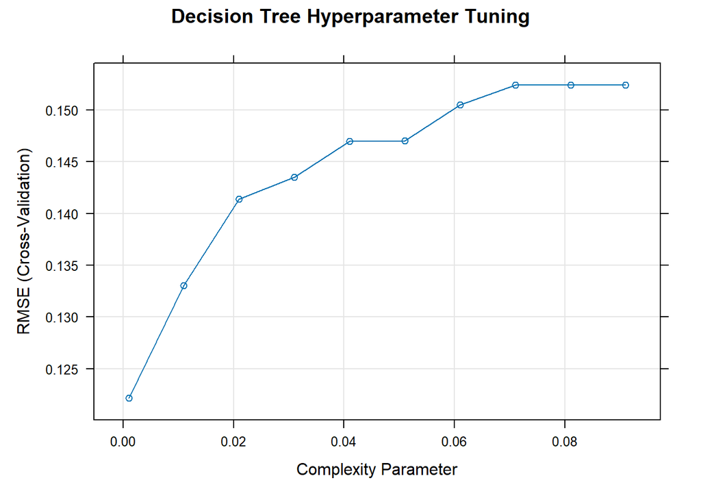

```r
plot(dt_model, main = "Decision Tree Hyperparameter Tuning")
```

```r
dt_pred <- predict(dt_model, X_test)
cat("Decision Tree training complete.\n")
```

```
## Decision Tree training complete.
```

### Linear Regression Model

```r
linear_model <- train(
  x = X_train,
  y = y_train,
  method = "lm",
  trControl = ctrl,
  preProcess = c("center", "scale"),
  metric = "RMSE"
)
print(linear_model)
```

```
## Linear Regression
##
## 2058 samples
##   26 predictor
##
## Pre-processing: centered (25), scaled (25), ignore (1)
## Resampling: Cross-Validated (10 fold)
## Summary of sample sizes: 1852, 1852, 1852, 1852, 1852, 1853, ...
## Resampling results:
##
##   RMSE       Rsquared   MAE
##   0.1363736  0.3752282  0.1064485
##
## Tuning parameter 'intercept' was held constant at a value of TRUE
```

```r
linear_pred <- predict(linear_model, X_test)
```

### Neural Network Model with Tuning

```r
nn_grid <- expand.grid(
  size = c(5, 10, 15, 20),
  decay = c(0, 0.001, 0.01, 0.1)
)
nn_model <- train(
  x = X_train,
  y = y_train,
  method = "nnet",
  trControl = ctrl_simple,
  tuneGrid = nn_grid,
  linout = TRUE,
  trace = FALSE,
  maxit = 1000,
  metric = "RMSE"
)
print(nn_model)
```

```
## Neural Network
##
## 2058 samples
##   26 predictor
##
## No pre-processing
## Resampling: Cross-Validated (5 fold)
## Summary of sample sizes: 1647, 1647, 1646, 1646, 1646
## Resampling results across tuning parameters:
##
##   size  decay  RMSE       Rsquared    MAE
##    5    0.000  0.1706753  0.04265965  0.1369104
##    5    0.001  0.1535068  0.28196317  0.1119824
##    5    0.010  0.1411459  0.36545705  0.1036737
##    5    0.100  0.1427154  0.34629600  0.1050191
##   10    0.000  0.1676942  0.06211118  0.1337962
##   10    0.001  0.1690413  0.25740375  0.1104214
##   10    0.010  0.1436610  0.37165243  0.1059018
##   10    0.100  0.1396447  0.40091579  0.1026521
##   15    0.000  0.1709968  0.06024081  0.1342948
##   15    0.001  0.1464075  0.34361875  0.1075686
##   15    0.010  0.1466760  0.37481458  0.1054407
##   15    0.100  0.1446542  0.38250632  0.1040472
##   20    0.000  0.1756837  0.04718781  0.1358110
##   20    0.001  0.1410639  0.36423545  0.1055471
##   20    0.010  0.1443302  0.35951877  0.1067041
##   20    0.100  0.1447708  0.38070990  0.1047519
##
## RMSE was used to select the optimal model using the smallest value.
## The final values used for the model were size = 10 and decay = 0.1.
```

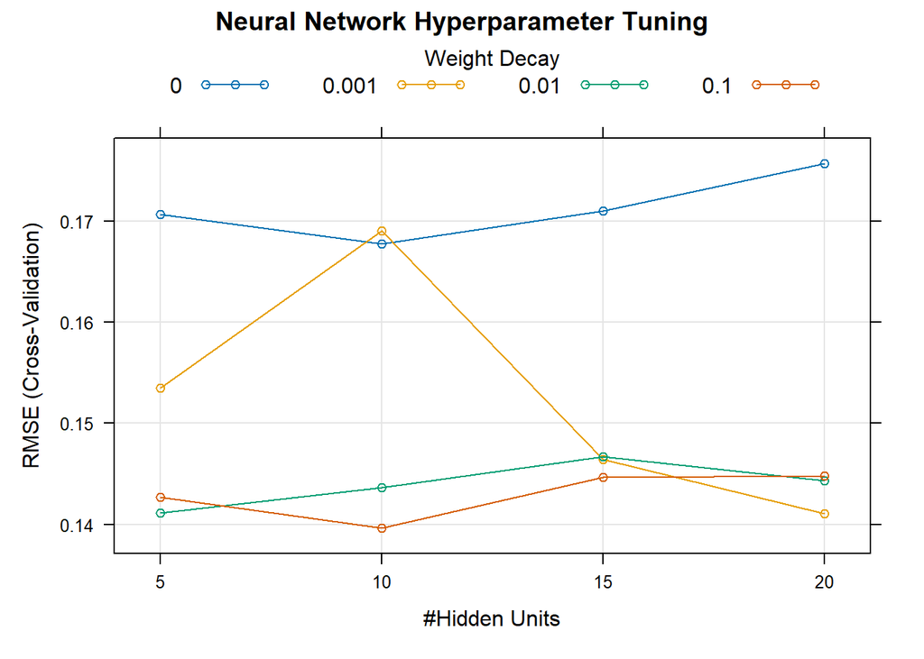

```r
plot(nn_model, main = "Neural Network Hyperparameter Tuning")
```

```r
nn_pred <- predict(nn_model, X_test)
```

### Random Forest Model with Tuning

```r
rf_grid <- expand.grid(
  mtry = c(2, 4, 6, 8, 10, 12)
)
rf_model <- train(
  x = X_train,
  y = y_train,
  method = "rf",
  trControl = ctrl,
  tuneGrid = rf_grid,
  ntree = 500,
  importance = TRUE,
  metric = "RMSE"
)
print(rf_model)
```

```
## Random Forest
##
## 2058 samples
##   26 predictor
##
## No pre-processing
## Resampling: Cross-Validated (10 fold)
## Summary of sample sizes: 1853, 1852, 1851, 1852, 1852, 1852, ...
## Resampling results across tuning parameters:
##
##   mtry  RMSE       Rsquared   MAE
##    2    0.1163532  0.5917889  0.08848722
##    4    0.1102480  0.6234084  0.08246250
##    6    0.1074842  0.6375274  0.07955159
##    8    0.1057797  0.6465254  0.07790089
##   10    0.1051641  0.6483115  0.07706957
##   12    0.1045666  0.6509294  0.07646263
##
## RMSE was used to select the optimal model using the smallest value.
## The final value used for the model was mtry = 12.
```

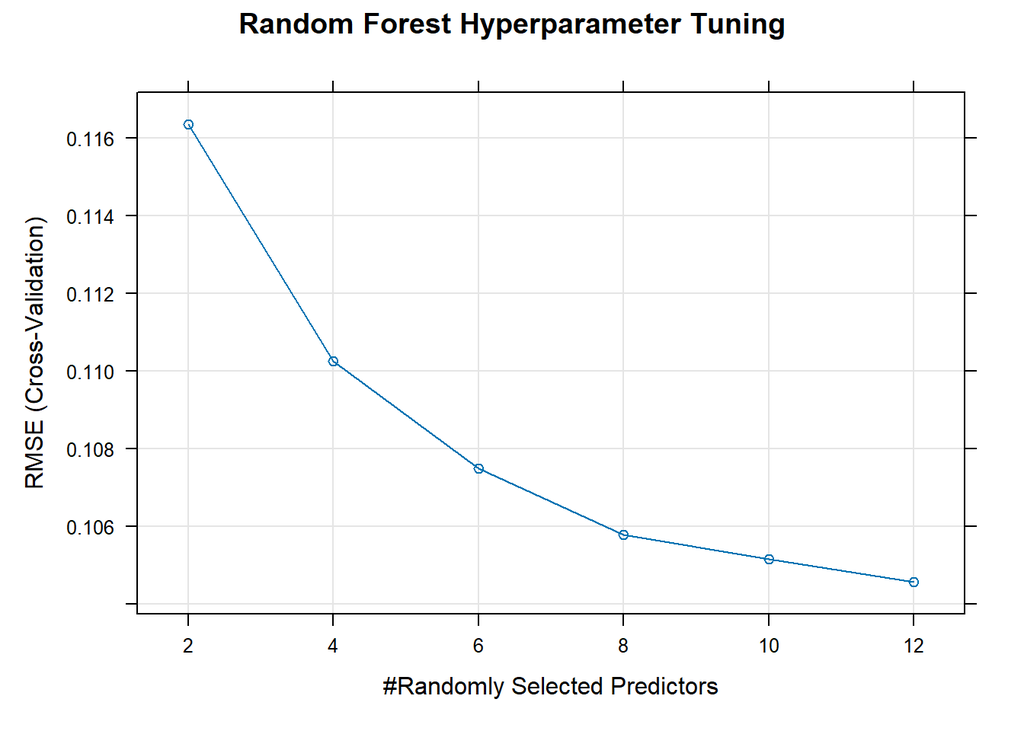

```r
plot(rf_model, main = "Random Forest Hyperparameter Tuning")
```

```r
rf_pred <- predict(rf_model, X_test)
```

## Model Performance Evaluation and Visualization

```r
model_results <- data.frame(
  Model = c("Linear Regression", "Decision Tree", "Random Forest", "Neural Network"),
  RMSE = c(postResample(linear_pred, y_test)[1],
           postResample(dt_pred, y_test)[1],
           postResample(rf_pred, y_test)[1],
           postResample(nn_pred, y_test)[1]),
  Rsquared = c(postResample(linear_pred, y_test)[2],
               postResample(dt_pred, y_test)[2],
               postResample(rf_pred, y_test)[2],
               postResample(nn_pred, y_test)[2])
)
print(model_results)
```

```
##               Model       RMSE  Rsquared
## 1 Linear Regression 0.13243826 0.4161105
## 2     Decision Tree 0.12625314 0.4928214
## 3     Random Forest 0.09658508 0.7110843
## 4    Neural Network 0.12701382 0.4777050
```

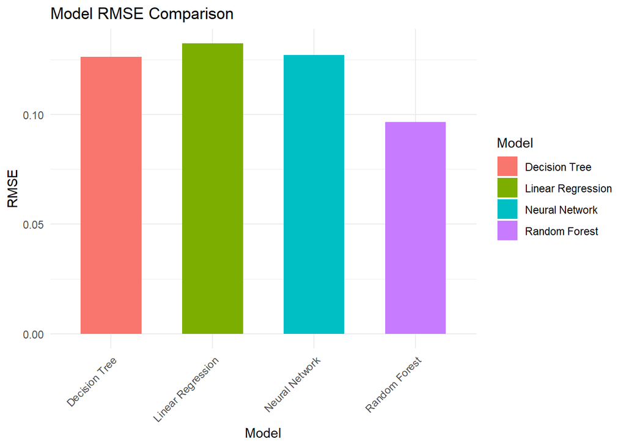

```r
plot1 <- ggplot(model_results, aes(x=Model, y=RMSE, fill=Model)) +
  geom_bar(stat="identity", width=0.6) +
  labs(title="Model RMSE Comparison", y="RMSE", x="Model") +
  theme_minimal() +
  theme(axis.text.x = element_text(angle = 45, hjust = 1))
plot2 <- ggplot(model_results, aes(x=Model, y=Rsquared, fill=Model)) +
  geom_bar(stat="identity", width=0.6) +
  labs(title="Model R-Squared Comparison", y="R-Squared", x="Model") +
  theme_minimal() +
  theme(axis.text.x = element_text(angle = 45, hjust = 1))
print(plot1)
```

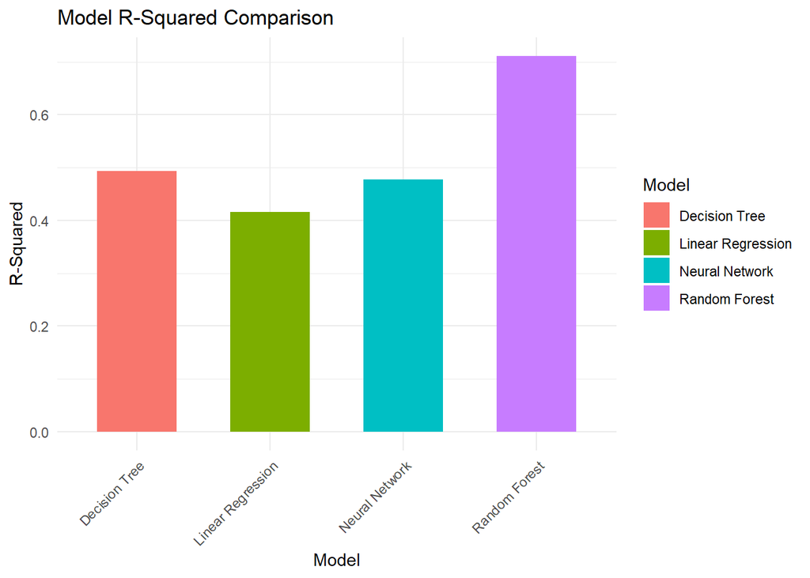

```r
print(plot2)
```

## Prediction and File Export

```r
testing <- testing %>%
  select(-c(PH, Balling, Hyd.Pressure1, Hyd.Pressure3, Alch.Rel, Density, Filler.Level)) %>%
  mutate(PH = "")

pred <- predict(dt_model, testing)

testing$PH <- pred

excel <- createWorkbook()
addWorksheet(excel, "PH Prediction")
writeData(excel, sheet = "PH Prediction", testing)
saveWorkbook(excel, "TestData.xlsx", overwrite = TRUE)
```